# ЕГЭ 2018 Вариант 18 EGE 2018 Variant 18

Использованы материалы:

The list of used links and books:

[ЕГЭ 2018. Математика. Профильный уровень. 20 вариантов тестов. Тематическая рабочая тетрадь.](https://drive.google.com/file/d/0B8CJrELbJAyodmtvbV8xcEtZXzA/view)

[SymPy Tutorials](http://nbviewer.jupyter.org/url/www.inp.nsk.su/~grozin/python/sympy.ipynb)

[LaTeX Mathematics](https://en.wikibooks.org/wiki/LaTeX/Mathematics)

[Метод рационализации неравенств (логарифмы)](http://internat.msu.ru/wp-content/uploads/2015/11/Metod-ratsionalizatsii-neravenstv-1.pdf)

```python
%%html
<style>
@import url('https://fonts.googleapis.com/css?family=Roboto&effect=3d|scuffed-steel|static|canvas-print|');
a, h1 h2, h3, h4, div.text_cell_render {font-family: 'Roboto'; text-shadow: 4px 4px 4px #aaa;}

h2, h3, div.output_prompt, div.output_area pre {color: slategray;}
h1, h4, div.input_prompt {color: steelblue;}
a, div.output_subarea {color: darkblue;}

span {text-shadow: 4px 4px 4px #aaa;}

body, div.output_stderr pre{background-color: aliceblue;}
div.output_stderr {background-color: slategray;}
</style>
```

```python
import numpy
import pandas
import math

import matplotlib.pyplot as plt
import matplotlib.patches as pat
from mpl_toolkits.mplot3d import Axes3D
from mpl_toolkits.mplot3d.art3d import Poly3DCollection, Line3DCollection

from __future__ import unicode_literals

import matplotlib
%matplotlib inline
```

```python
import sympy
from sympy import *
from sympy import init_printing
init_printing()
```

```python
answer_dictionary = dict()
```

## Часть 1 Part 1

[figure not shown]

### Задание 1 / Task 1

Магазин делает пенсионерам скидку на определенное количество процентов от цены покупки.

Банка сока стоит в магазине 80 рублей.

Пенсионер заплатил за банку сока 76 рублей.

Сколько процентов составляет скидка для пенсионеров?

The store makes a discount for pensioners for a certain number of percent of the purchase price.

A juice jar costs 80 rubles in the store.

The pensioner paid 76 rubles for a jar of juice.

What percentage is the discount for pensioners?

Определим размер скидки в процентах

Let's define the size of the discount in percent

$100 * (80 - 76) / 80 = 5$

### Ответ / Answer: 5

```python
answer_dictionary[1] = str(int(100 * (80 - 76) / 80))
```

[figure not shown]

### Задание 2 / Task 2

На диаграмме показана среднемесячная температура воздуха в Рио-де-Жанейро за каждый месяц 2009 года.

По горизонтали указываются месяцы, по вертикали - температура в градусах Цельсия.

Определите по диаграмме, сколько в 2009 году было месяцев, когда среднемесячная температура превосходила $25^o C$.

The diagram shows the average monthly air temperature in Rio de Janeiro for each month of 2009.

Months are indicated horizontally, vertically - temperature in degrees Celsius.

Determine by the diagram how much in 2009 there were months when the average monthly temperature exceeded $25^o C$.

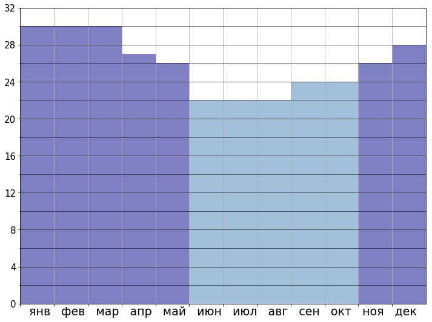

```python
months = ['янв','фев','мар','апр','май','июн','июл','авг','сен','окт','ноя','дек']
df=pandas.DataFrame({'months': months,
                     't': [30,30,30,27,26,22,22,22,24,24,26,28]})
fig,ax = plt.subplots()
df.plot(kind='bar', x='months', ax=ax,
        figsize=(12,9), grid=True,
        color='steelblue', alpha=0.5, align='edge', width=1)

for p in [0,1,2,3,4,10,11]:
    ax.patches[p].set_facecolor('darkblue')

plt.xticks(visible=False)
plt.xlabel('   '.join(months), fontsize=19)

ax.set_yticks(numpy.arange(0, 36, 4))
ax.set_yticklabels(['0','4','8','12','16',
                    '20','24','28','32'], fontsize=15)
ax.set_yticks(numpy.arange(0, 36, 2), minor=True)
ax.grid(which='minor', alpha=0.7, color='black')

ax.legend().set_visible(False)

plt.xlim(0,12)
plt.ylim(0,32);
```

### Ответ / Answer: 7

```python
answer_dictionary[2]=str(7)
```

[figure not shown]

### Задание 3 / Task 3

Найдите площадь параллелограмма, вершинами которого являются точки с координатами

Find the area of the parallelogram whose vertices are the points with coordinates

$(1;4), (1;6), (5;3), (5;1)$.

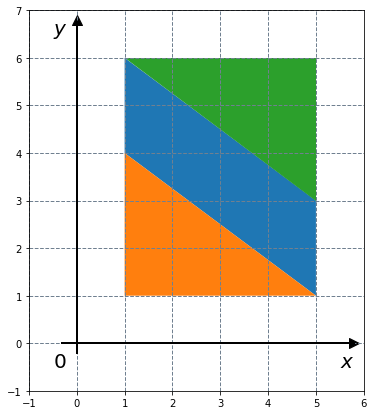

```python
plt.figure(figsize=(6,7))
plt.grid(c='slategray', ls='--', lw=1)

plt.axhline(0, 0.1, 0.97, c='black', lw=2)
plt.axvline(0, 0.1, 0.97, c='black', lw=2)

XY = [[[1,1,5,5], [4,6,3,1]],
      [[1,1,5], [1,4,1]],
      [[1,5,5], [6,6,3]]]
for x,y in XY:
    plt.fill(x,y)

plt.text(5.5,-0.5,r'$x$', fontsize=20)
plt.text(-0.5,6.5,r'$y$', fontsize=20)
plt.text(-0.5,-0.5,r'$0$', fontsize=20)

plt.scatter(0,6.8, marker='^', s=100, c='black')
plt.scatter(5.8,0, marker='>', s=100, c='black')

plt.xlim(-1,6)
plt.ylim(-1,7);
```

$5 * 4 - \large{\frac{3 * 4}{2} - \frac{3 * 4}{2}}$$ = 8$

### Ответ / Answer: 8

```python
answer_dictionary[3]=str(int(5*4 - 3*4/2 - 3*4/2))
```

[figure not shown]

### Задание 4 / Task 4

На турнир по шахматам прибыли 26 участников, в том числе близнецы Коля и Толя.

Для проведения жеребьевки первого тура участников случайным образом разбивают на две группы по 13 человек.

Найдите вероятность того, что Коля и Толя попадут в разные группы.

26 participants came to the chess tournament, including twins Kolya and Tolya.

For the first draw, participants are randomly divided into two groups of 13 people.

Find the probability that Kolya and Tolya will be in the different groups.

Если при жеребьевке Коля попал в одну из групп:

- вместе с ним в эту же группу случайным образом попадут еще 12 участников из оставшихся 25;
- 13 из 25 оставшихся участников попадут в другую группу.

Вероятность Толи быть в другой группе равна 13/25 = 0.52.

Ситуация симметрична для каждого из близнецов.

If Kolya got into one of the groups at the draw:

- together with him in the same group will randomly get 12 more participants from the remaining 25;
- 13 of the 25 remaining participants will be in another group.

Tolya's probability of being in the other group is 13/25 = 0.52.

The situation is symmetrical for each of the twins.

```python
answer_dictionary[4]=str(13/25)
```

[figure not shown]

### Задание 5 / Task 5

Найдите корень уравнения:

Find the root of the equation:

$\log_{4}{(18 - 5 * x)} = 2 * log_{4}{3}$

1) Область допустимых значений: / Range of admissible values:

$18 - 5 * x > 0$

$x < 3.6$

2) Преобразования уравнения: / Equation transformations:

$\log_{4}{(18 - 5 * x)} = 2 * log_{4}{3}$

$\log_{4}{(18 - 5 * x)} = log_{4}{3^2}$

$18 - 5 * x = 9$

$5 * x = 9$

$x = 1.8$

### Ответ / Answer: 1.8

```python
answer_dictionary[5] = str(1.8)
```

[figure not shown]

### Задание 6 / Task 6

Около окружности, радиус которой равен 3 описан многоугольник, периметр которого равен 18.

Найдите его площадь.

Around a circle with radius 3, a polygon is circumscribed, the perimeter of which is 18.

Find polygon's area.

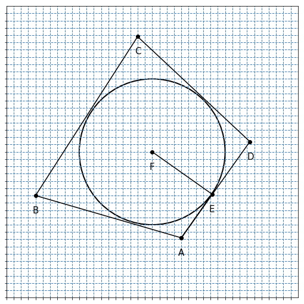

```python
f = plt.figure(figsize=(9,9))
ax = f.add_subplot(1, 1, 1, aspect=1)
ax.grid(c='steelblue', ls='--', lw=1)

circle = pat.Circle((0, 0), 5, lw=2,
                edgecolor='black', facecolor='none')
ax.add_artist(circle)

XY = [[[2,-8,-1,6.7,2,4.1,0], [-5.9,-3,7.9,0.7,-5.9,-2.9,0]]]
L = ['A','B','C','D','','E','F']

for x,y in XY:
    plt.plot(x,y,'-o',c='black')
for i in range(7):
    plt.text(XY[0][0][i]-0.2,XY[0][1][i]-1.2,
             L[i],fontsize=15)

plt.xlim(-10,10)
plt.ylim(-10,10)
plt.xticks(numpy.arange(-10, 10, step=0.5), visible=False)
plt.yticks(numpy.arange(-10, 10, step=0.5), visible=False);
```

Площадь описанного около окружности многоугольника равна произведению полупериметра этого многоугольника на радиус этой окружности:

The area of a polygon circumscribed around a circle is equal to the product of the half-perimeter of this polygon by the radius of this circle:

$S_{ABCD} = EF * (AB + BC + CD + AD) / 2 = 3 * 18 / 2 = 27$

### Ответ / Answer: 27

```python
answer_dictionary[6] = str(27)
```

[figure not shown]

### Задание 7 / Task 7

На рисунке изображен график функции $y = f(x)$ и отмечены точки -5, -3, 3, 7.

В какой из этих точек значение производной наименьшее?

В ответе укажите эту точку.

The figure shows the graph of the function $y = f (x)$ and points -5, -3, 3, 7 are marked.

Which of these points corresponds to the least value of the derivative?

In the answer, specify this point.

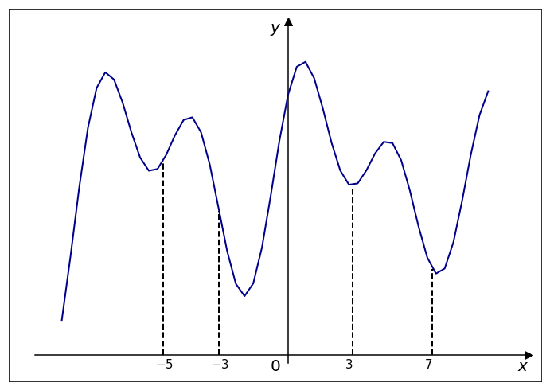

```python
f = plt.figure(figsize=(12,9))
ax = f.add_subplot(1, 1, 1, aspect=1)

ax.axhline(0, 0.05, 0.97, c='black')
ax.axvline(0.5, 0.05, 0.97, c='black')

def f(x,a=5,b=0.4,c=1.3,d=-6.1,e=7):
    exp = (math.pow(x, 2) + math.pow(x, 5)) * (-0.1)**5
    return a * math.exp(exp) * math.cos(b*x+d) * math.sin(c*x)+e

x = numpy.linspace(-8,8)
y = [f(el) for el in x]
ax.plot(x, y, c='darkblue', lw=2)


v = numpy.array([[-4.2,-2.1,2.9,5.9], 4*[-0.5],
                 [r'$-5$',r'$-3$',r'$3$',r'$7$']])

for el in v[0]:
    ax.plot([float(el),float(el)], [0,f(float(el))], lw=2, ls='--', c='black')

for i in range(4):
    plt.text(float(v[0][i])-0.3,float(v[1][i]),v[2][i],fontsize=15)

plt.text(9.1,-0.6,r'$x$', fontsize=20)
plt.text(-0.2,12.1,r'$y$', fontsize=20)
ax.scatter(0.5,12.5, marker='^', s=100, c='black')
ax.scatter(9.5,0, marker='>', s=100, c='black')
plt.text(-0.2,-0.6,r'$0$', fontsize=20)

plt.xlim(-10,10)
plt.ylim(-1,13)

plt.xticks([], visible=False)
plt.yticks([], visible=False);
```

Максимальным по модулю и отрицательным является тангенс угла наклона касательной к кривой $y = f (x)$ точке -3,

что соответствует минимальному значению производной в этой точке.

The maximum by the modulus and negative tangent is reached for the slope angle of the tangent to the curve $y = f (x)$ in the point -3,

which corresponds to the minimum value of the derivative at this point.

### Ответ / Answer: -3

```python
answer_dictionary[7] = str(-3)
```

[figure not shown]

### Задание 8 / Task 8

Цилиндр описан около шара. Объем цилиндра равен 15. Найдите объем шара.

A cylinder is circumscribed around a ball. The volume of the cylinder is 15. Find the volume of the ball.

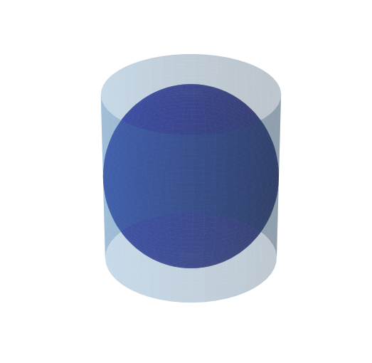

```python
f = plt.figure(figsize=(9,9))
ax = f.add_subplot(111, projection='3d')

def create_sphere(center_x,center_y,center_z,radius):
    u, v = numpy.mgrid[0:2*numpy.pi:50j, 0:numpy.pi:50j]
    x_grid = center_x + radius*numpy.cos(u)*numpy.sin(v)
    y_grid = center_x + radius*numpy.sin(u)*numpy.sin(v)
    z_grid = center_x + radius*numpy.cos(v)
    return x_grid,y_grid,z_grid

Xc,Yc,Zc = create_sphere(2.5,2.5,2.5,2.5)
ax.plot_surface(Xc, Yc, Zc, alpha=0.5, color='darkblue')

def create_cylinder(center_x,center_y,radius,height):
    z = numpy.linspace(0, height, 50)
    theta = numpy.linspace(0, 2*numpy.pi, 50)
    theta_grid, z_grid = numpy.meshgrid(theta, z)
    x_grid = radius * numpy.cos(theta_grid) + center_x
    y_grid = radius * numpy.sin(theta_grid) + center_y
    return x_grid,y_grid,z_grid

Xc,Yc,Zc = create_cylinder(2.5,2.5,2.5,5)
ax.plot_surface(Xc, Yc, Zc, alpha=0.3, color='steelblue')

plt.axis('off');
```

Радиусы шара и основания цилиндра равны $R$. Высота цилиндра равна $2 * R$.

The radii of the ball and the base of the cylinder are equal to $R$. The height of the cylinder is $2 * R$.

Объем цилиндра равен произведению площади основания ны высоту.

The volume of the cylinder is equal to the product of the base area and the height.

$V_{cylinder} = \pi * R^2 * 2 * R = 2 * \pi * R^3$

$V_{ball} = \frac{4}{3} * \pi * R^3 \implies V_{ball} \ / \ V_{cylinder} = \frac{4}{3} * \pi * R^3 \ / \ 2 * \pi * R^3 = \frac{2}{3}$

$V_{ball} = 2 * V_{cylinder} \ / \ 3 = 2 * 15 / 3 = 10$

### Ответ / Answer: 10

```python
answer_dictionary[8] = str(int(2*15/3))
```

[figure not shown]

### Задание 9 / Task 9

Найдите значение выражения

Find the value of the expression

$\large{3 * \sqrt[4]{64} * \sqrt[12]{64}}$

$\large{3 * \sqrt[4]{64} * \sqrt[12]{64} = 3 * 64^{\frac{1}{4}} * 64^{\frac{1}{12}} = 3 * 64^{\frac{1}{4} + \frac{1}{12}} = 3 * 64^{\frac{1}{3}} = }$$3 * 4 = 12$

### Ответ / Answer: 12

```python
answer_dictionary[9] = str(12)
```

[figure not shown]

### Задание 10 / Task 10

Два тела массой $m = 9 \ кг$ каждое движутся с одинаковой скоростью $v = 10 \ м/с$ под углом $2 \alpha$ друг к другу.

Энергия (в джоулях), выделяющаяся при их абсолютно неупругом соударении, определяется выражением $Q = m * v^2 * sin^2 \alpha$.

Под каким наименьшим углом $2 \alpha$ должны двигаться тела, чтобы в результате соударения выделилось не менее 450 джоулей?

Two solids of mass $m = 9 \ kg$ each move with the same velocity $v = 10 \ m/s$ at an angle $2 \alpha$ to each other.

Energy (in joules), which is released during their absolutely inelastic collision, is determined by the expression $Q = m * v^2 * sin^2 \alpha$.

Under what smallest angle $2 \alpha$ should the solids move so that as a result of the collision at least 450 joules are released?

Подставим имеющиеся данные в уравнение энергии.

При вычислениях учитываем, что угол должен быть положительным и наименьшим.

Let's substitute the available data in the energy equation.

In the calculations, we take into account that the angle must be positive and least.

$450 = 9 * 10^2 * sin^2 \alpha$

$sin^2 \alpha = \large{\frac{1}{2}}$

$sin \ \alpha = \large{\frac{\sqrt{2}}{2}}$

$\alpha = 45^o$

$2*\alpha = 90^o$

### Ответ / Answer: 90

```python
answer_dictionary[10] = str(90)
```

[figure not shown]

### Задание 11 / Task 11

На изготовление 468 деталей первый рабочий затрачивает на 8 часов меньше, чем второй рабочий на изготовление 520 деталей.

Известно, что первый рабочий за час делает на 6 деталей больше, чем второй.

Сколько деталей в час делает первый рабочий.

For the production of 468 details, the first worker spends 8 hours less than the second worker to produce 520 details.

It is known that the first worker per hour makes 6 details more than the second one.

How many details per hour does the first worker?

Пусть $x$ деталей в час - производительность труда первого рабочего, тогда $x - 6$ деталей в час - второго.

$\large{\frac{520}{x - 6} - \frac{468}{x}} = $ $8$

$\large{\frac{520 * x - 468 * (x - 6)}{x * (x - 6)}} = $ $8$

$52 * x + 2808 = 8 * x^2 - 48 * x$

$2 * x^2 - 25 * x - 702 = 0$

$D = 625 - 4 * 2 * (-702) = 6241$

$x = (25 + 79) / 4 = 26$

### Ответ / Answer: 26

```python
answer_dictionary[11] = str(26)
```

[figure not shown]

### Задание 12 / Task 12

Найдите точку максимума функции

Find the maximum point of the function

$y = - \large{\frac{x}{x^2 + 625}}$

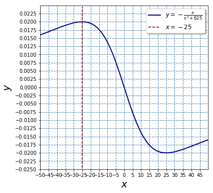

```python
f = plt.figure(figsize=(6,6))
ax = f.add_subplot(1, 1, 1)
ax.grid(c='steelblue', ls='--', lw=1)

def f(x):
    return - x / (x ** 2 + 625)

x = numpy.linspace(-50,50)
y = [f(el) for el in x]
ax.plot(x, y, c='darkblue', lw=2,
        label=r'$y = - \frac{x}{x^2 + 625}$')

ax.axvline(-25, 0.01, 0.99, c='darkred',
           ls='--',label=r'$x=-25$')

plt.xlim(-50,50)
plt.ylim(-0.025,0.025)
plt.xticks(numpy.arange(-50,50, step=5))
plt.yticks(numpy.arange(-0.025,0.025, step=0.0025))

plt.xlabel(r'$x$', fontsize=20)
plt.ylabel(r'$y$', fontsize=20)
plt.legend(fontsize=12, shadow=True, loc=1);
```

Наибольших значений непрерывная функция может достигать в точках, где первая производная равна нулю, а вторая производная отрицательна.

The maximum value of a continuous function can be reached at points where the first derivative is equal to zero, and the second derivative is negative.

```python
x = Symbol('x')
y = - x / (x ** 2 + 625)
```

```python
# производная | the first derivative
diff(y,x)
```

$$\frac{2 x^{2}}{\left(x^{2} + 625\right)^{2}} - \frac{1}{x^{2} + 625}$$

```python
# производная равна нулю ∣ the first derivative is 0
solve(diff(y,x),x)
```

$$\left [ -25, \quad 25\right ]$$

```python
# вторая производная / the second derivative
diff(diff(y,x),x)
```

$$- \frac{8 x^{3}}{\left(x^{2} + 625\right)^{3}} + \frac{6 x}{\left(x^{2} + 625\right)^{2}}$$

```python
# y''(-25) < 0 => max
diff(diff(y,x),x).subs({x:-25})
```

$$- \frac{1}{31250}$$

```python
# y''(25) > 0 => min
diff(diff(y,x),x).subs({x:25})
```

$$\frac{1}{31250}$$

### Ответ / Answer: -25

```python
answer_dictionary[12] = str(-25)
```

## Часть 2 Part 2

[figure not shown]

### Задание 13 / Task 13

a) Найдите корень уравнения:

a) Find the root of the equation:

$3 * tg^2 x - 4 * tg \ x - 7 = 0$.

б) Найдите все корни этого уравнения, принадлежащие промежутку

b) Find all the roots of this equation that belong to the interval

$\bigg[-\large{\frac{\pi}{2}}$$;\pi \bigg]$.

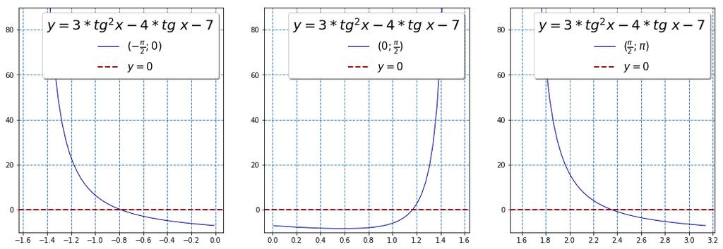

```python
f,[ax1,ax2,ax3] = plt.subplots(nrows=1,ncols=3,figsize=(18, 6))

x1 = numpy.linspace(-1.56,-0.01)
x2 = numpy.linspace(0.01,1.56)
x3 = numpy.linspace(1.58,3.14)
def f(el):return 3 * math.tan(el) ** 2 - 4 * math.tan(el) - 7
y1 = [f(el) for el in x1]
y2 = [f(el) for el in x2]
y3 = [f(el) for el in x3]

ax1.plot(x1, y1, c='darkblue', lw=1,
        label=r'$(-\frac{\pi}{2};0)$')
ax2.plot(x2, y2, c='darkblue', lw=1,
        label=r'$(0;\frac{\pi}{2})$')
ax3.plot(x3, y3, c='darkblue', lw=1,
        label=r'$(\frac{\pi}{2};\pi)$')

for p in [ax1,ax2,ax3]:
    p.grid(c='steelblue', ls='--', lw=1)
    p.set_ylim([-10,90])

    p.axhline(0, c='darkred',ls='--',lw=2,label=r'$y = 0$')

    p.legend(title=r'$y = 3 * tg^2 x - 4 * tg \ x - 7$',
          fontsize=15, shadow=True)
    p.get_legend().get_title().set_fontsize(20)
```

а)

1) Область допустимых значений / Range of admissible values

$x \neq \frac{\pi}{2} \pm \pi * n, n \in \mathbb{N}$

2) The transformations of the equation

$3 * tg^2 x - 4 * tg \ x - 7 = 0$

$D = 16 - 4 * 3 * (-7) = 100$

$tg \ x = \large{\frac{4 \pm \sqrt{100}}{2 * 3}}$

$tg \ x = \large{\frac{7}{3}}$$ \; \lor \; tg \ x = -1$

$x = arctg \bigg(\large{\frac{7}{3}}$$\bigg) \pm \pi * k, k \in \mathbb{N} \; \lor \; x = - \large{\frac{\pi}{4}}$$ \pm \pi * m, m \in \mathbb{N}$

б)

$-\large{\frac{\pi}{4}}$$; \; arctg \bigg(\large{\frac{7}{3}}$$\bigg); \; \large{\frac{3*\pi}{4}}$

### Ответ / Answer:

#### а) $arctg \bigg(\large{\frac{7}{3}}$$\bigg) \pm \pi * k, \;$$- \large{\frac{\pi}{4}}$$ \pm \pi * m; \; k,m \in \mathbb{N}$

#### б) $-\large{\frac{\pi}{4}}$$; \; arctg \bigg(\large{\frac{7}{3}}$$\bigg); \; \large{\frac{3*\pi}{4}}$

```python
# check the decision method
x = Symbol('x')
g = 3 * (tan(x)) ** 2  - 4 * tan(x) -7
```

```python
g
```

$$3 \tan^{2}{\left (x \right )} - 4 \tan{\left (x \right )} - 7$$

```python
solve(g,x)
```

$$\left [ - \frac{\pi}{4}, \quad \operatorname{atan}{\left (\frac{7}{3} \right )}\right ]$$

```python
N(-pi/2), N(solve(g,x)[0]), N(solve(g,x)[1]), N(solve(g,x)[0]+pi), N(pi)
```

$$\left ( -1.5707963267949, \quad -0.785398163397448, \quad 1.16590454050981, \quad 2.35619449019234, \quad 3.14159265358979\right )$$

```python
answer_dictionary[13] = 'а) arctg(7/3)±π∗k, -π/4±π∗m; k,m∈ℕ; б) -π/4,arctg(7/3),3*π/4'
```

[figure not shown]

### Задание 14 / Task 14

В правильной треугольной пирамиде SABC с вершиной S, все ребра которой равны 2:

- точка M - середина ребра AB,
- точка O - центр основания пирамиды,
- точка F делит отрезок SO в отношении 3 : 1, считая от вершины пирамиды.

а) Докажите, что прямая MF перпендикулярна прямой SC.

б) Найдите угол между плоскостью MBF и плоскостью ABC.

In the right triangular pyramid SABC with the vertex S, all edges of which are equal to 2:

- the point M is the midpoint of the edge AB,
- the point O - the center of the base of the pyramid,
- the point F divides the segment SO in a ratio of 3 : 1, counting from the top of the pyramid.

a) Prove that the line MF is perpendicular to the line SC.

b) Find the angle between the plane MBF and the plane ABC.

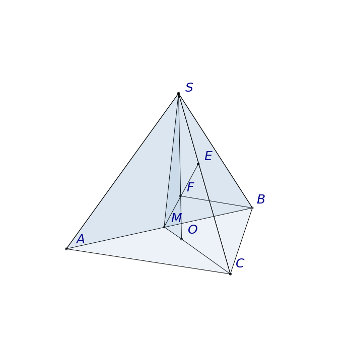

```python
f = plt.figure(figsize=(12,12))
ax = f.add_subplot(111, projection='3d')

v = numpy.array([[-1,-1,-1],[0.5,1,-1],[1,-0.5,-1],[0,0,1],
                 [0.1,-0.1,-1],[-0.23,0.04,-1],[0.06,-0.06,-0.4],[0.62,-0.62,0.5]])
letters = [r'$A$', r'$B$',r'$C$',r'$S$',r'$O$',r'$M$',r'$F$',r'$E$']

ax.scatter3D(v[:, 0],v[:, 1],v[:, 2],color='black')

verts = [ [v[0],v[1],v[3]], [v[0],v[2],v[3]],
          [v[2],v[1],v[3]], [v[3],v[4],v[5]],
          [v[7],v[5]],[v[2],v[4]],[v[1],v[6]] ]

piramid = Poly3DCollection(verts,lw=1,alpha=0.1,
                           edgecolors='black',facecolor='none')
piramid.set_facecolor('steelblue')
ax.add_collection3d(piramid)
for i in range(8):
    ax.text(v[i][0]-0.2,v[i][1]+0.5,v[i][2]-0.25,
            letters[i],fontsize=25,color='darkblue')

plt.axis('off');
```

а)

$SO \cap MC = O, F \in SO \implies MF \subset (MSC) \implies MF \cap SC = E$

$AB = BC = AC = SA = SB = SC = 2, \; AM = MB = 1 \implies MC = \sqrt{2^2 - 1^2} = \sqrt{3}$

O - точка пересечения медиан правильного $\triangle ABC$

O is the point of intersection of the medians of the equilateral $\triangle ABC$

$\implies CO/MO = 2/1 \implies CO = 2\sqrt{3}/3, MO = \sqrt{3}/3$

$\triangle SOC: SO = \sqrt{SC^2 - SO^2} = \sqrt{2^2 - (2\sqrt{3}/3)^2} = 2\sqrt{6}/3$

$SF:FO = 3:1 \implies FO = SO/4 = \sqrt{6}/6$

$\triangle EMC: ctg\angle EMC = MO/OF = \sqrt{3}/3 : \sqrt{6}/6 = \sqrt{2}; \; ctg\angle ECM = CO/SO = 2\sqrt{3}/3 : 2\sqrt{6}/3 = \sqrt{2}/2$

$ctg(\angle EMC + \angle ECM) = (ctg\angle EMC * ctg\angle ECM - 1)/(ctg\angle EMC + ctg\angle ECM) = (\sqrt{2} * \sqrt{2}/2 - 1) / (\sqrt{2} + \sqrt{2}/2) = 0$

$\angle EMC + \angle ECM = 90^o \implies \angle MEC = 90^o \implies ME \bot SC \equiv MF \bot SC$

б)

По теореме о трех перпендикулярах

By the theorem on three perpendiculars

$SM \bot AB, SO \bot MC \implies MO \bot AB, FO \bot MO \implies MO \bot AB \implies \angle(MBF,ABC) = \angle FMO$

$tg\angle FMO = FO : MO = \sqrt{6}/6 : \sqrt{3}/3 = \sqrt{2}/2 \implies = \angle FMO = arctg (\sqrt{2}/2)$

### Ответ / Answer: б) $arctg (\frac{\sqrt{2}}{2})$

```python
answer_dictionary[14] = 'б) arctg(√2/2)'
```

[figure not shown]

### Задание 15 / Task 15

Решите неравенство:

Solve the inequality:

$1 + \log_6{(4 - x)} \leq \log_6{(16 - x^2)}$

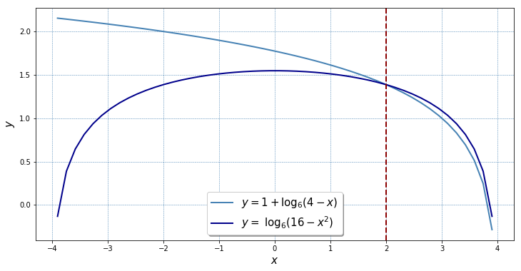

```python
x = numpy.linspace(-3.9,3.9)
y1 = [1 + math.log(4 - el,6) for el in x]
y2 = [math.log(16 - el ** 2,6) for el in x]

plt.figure(figsize=(12,6))
plt.plot(x, y1, c='steelblue', lw=2, label=r'$y = 1 + \log_6{(4 - x)}$')
plt.plot(x, y2, c='darkblue', lw=2, label=r'$y = \ \log_6{(16 - x^2)}$')

plt.grid(c='steelblue',ls='--',lw=0.5)
plt.axvline(2, c='darkred',ls='--',lw=2)

plt.xlabel(r'$x$', fontsize=15)
plt.ylabel(r'$y$', fontsize=15)
plt.legend(fontsize=15, shadow=True);
```

1) Область допустимых значений / Range of admissible values

$\begin{cases} 4 - x > 0 \\ 16 - x^2 > 0 \end{cases} \iff \begin{cases} x < 4 \\ (4 - x) * (4 + x) > 0 \end{cases} \iff -4 < x < 4$

2) Преобразования неравенства / Inequality transformations

$1 + \log_6{(4 - x)} \leq \log_6{(16 - x^2)}$

$\log_6{(16 - x^2)} - \log_6{(4 - x)} \geq 1$

$\log_6{\large{\frac{16 - x^2}{4 - x}}} \geq 1$

$\log_6{(4 + x)} \geq 1$

$\log_6{(4 + x)} \geq \log_6{6}$

$4 + x \geq 6$

$x \geq 2$

3) 1), 2) $\implies 2 \leq x <4$

### Ответ / Answer: $[2;4)$

```python
answer_dictionary[15] ='[2;4)'
```

[figure not shown]

### Задание 16 / Task 16

В прямоугольном треугольнике ABC катеты AC и BC равны соответственно 16 и 12.

Проведена окружность радиусом BC с центром в точке B.

К ней в точке K проведена касательная, параллельная гипотенузе.

Катет BC продолжен до пересечения с проведенной касательной в точке D.

а) Докажите, что треугольники ABC и BDK подобны.

б) Определите, на какое расстояние продолжили катет.

In the right triangle ABC, the catheti AC and BC are 16 and 12, respectively.

A circle with a radius BC centered at point B is drawn.

A tangent line parallel to the hypotenuse is drawn to this circle at point K.

The cathetus BC is continued to the intersection with the tangent line at the point D.

a) Prove that the triangles ABC and BDK are similar.

b) Determine how far the cathetus was continued.

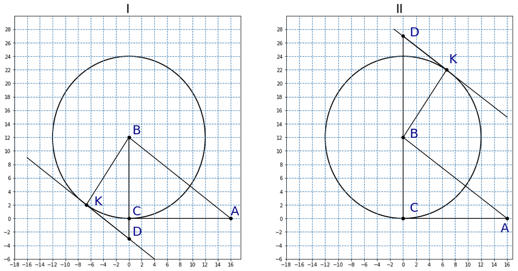

```python
f,[ax1,ax2] = plt.subplots(nrows=1,ncols=2,figsize=(18, 9))

ax1.plot([4,-16],[-6,9],c='black')
ax1.plot([0,16,0,0,-6.7,0],[0,0,12,-3,2,12],'-o',c='black')

ax2.plot([16,-1.4],[15,28],c='black')
ax2.plot([0,16,0,6.7,0,0],[0,0,12,22,27,0],'-o',c='black')

for p in [ax1,ax2]:
    p.grid(c='steelblue', ls='--', lw=1)
    p.set_ylim([-18,18])
    p.set_ylim([-6,30])
    p.set_xticks(numpy.arange(-18,18,step=2))
    p.set_yticks(numpy.arange(-6,30,step=2));

    circle = pat.Circle((0,12),12,lw=2,
                        edgecolor='black',
                        facecolor='none')
    p.add_artist(circle)

XYL1 = [[16,0.5,0.5,0.5,-5.5],
       [0.5,12.5,0.5,-2.5,2],
       ['A','B','C','D','K']]
for i in range(5):
    ax1.text(XYL1[0][i],XYL1[1][i],XYL1[2][i],
             fontsize=25,color='darkblue')

XYL2 = [[15,1,1,1,7],
       [-2,12,1,27,23],
       ['A','B','C','D','K']]
for i in range(5):
    ax2.text(XYL2[0][i],XYL2[1][i],XYL2[2][i],
             fontsize=25,color='darkblue')

ax1.set_title('I',fontsize=25)
ax2.set_title('II',fontsize=25);
```

а)

Радиус окружности, проведённый через точку касания, перпендикулярен касательной прямой.

$\triangle ABC, \triangle BDK: BC \bot AC, BK \bot DK, DK \| AB \implies \angle ACB = \angle BKD, \angle ABC = \angle BDK \implies \triangle ABC \sim \triangle BDK$

a)

The radius of the circle drawn through the point of tangency is perpendicular to the tangent line.

$\triangle ABC, \triangle BDK: BC \bot AC, BK \bot DK, DK \| AB \implies \angle ACB = \angle BKD, \angle ABC = \angle BDK \implies \triangle ABC \sim \triangle BDK$

б)

Стороны подобных треугольников пропорциональны.

$AC : BK = BC : DK, \; BC = BK \implies DK = BC^2 / AC = 12^2 / 16 = 9$

По теореме Пифагора:

$BD = \sqrt{BK^2 + DK^2} = \sqrt{12^2 + 9^2} = \sqrt{12^2 + 9^2} = 15$

Для двух случаев продления отрезка BC:

I. $CD = BD - BC = 15 - 12 = 3$

II. $BD = 15$

b)

The sides of similar triangles are proportional.

$AC : BK = BC : DK, \; BC = BK \implies DK = BC^2 / AC = 12^2 / 16 = 9$

By the Pythagorean theorem:

$BD = \sqrt{BK^2 + DK^2} = \sqrt{12^2 + 9^2} = \sqrt{12^2 + 9^2} = 15$

For two cases of extension of the segment BC:

I. $CD = BD - BC = 15 - 12 = 3$

II. $BD = 15$

### Ответ / Answer: б) 3 ∨ 15

```python
answer_dictionary[16] ='3 ∨ 15'
```

[figure not shown]

### Задание 17 / Task 17

1 января 2015 года Тарас Павлович взял в банке 1.1 млн рублей в кредит.

Схема выплаты кредита следующая:

- 1-го числа каждого следующего месяца банк начисляет 2 процента на оставшуюся сумму долга (то есть увеличивает долг на 2%),
- затем Тарас Павлович переводит в банк платёж.

На какое минимальное количество месяцев Тарас Павлович может взять кредит, чтобы ежемесячные выплаты были не более 220 тыс. рублей?

January 1, 2015, Taras Pavlovich took the loan of 1.1 million rubles in the bank.

The loan repayment scheme is as follows:

- on the 1st of each following month the bank charges 2 percent for the remaining amount of debt (thus, it increases the debt by 2%),
- then Taras Pavlovich transfers to the bank the next payment.

What is the minimum number of months for Taras Pavlovich to take the loan, so that monthly payments are not more than 220 thousand rubles?

1) 1 100 тысяч рублей / 220 тысяч рублей = 5 $\implies$ кредит по указаннй схеме нужно выплачивать больше 5 месяцев.

1) 1 100 thousand rubles / 220 thousand rubles = 5 $\implies$ the loan under the scheme should be paid more than 5 months.

2) Рассмотрим случай, когда срок выплаты равен 6 месяцам.

2) Let's consider the case when the repayment period is 6 months.

| Месяц / Month | Долг / Debt | Долг - Оплата = Остаток / Dept - Payment = Balance |
| --- | --- | --- |
| 1 | $1100 * 1.02 = 1122$ | $1122 - 220 = 902$ |
| 2 | $902 * 1.02 = 920.04$ | $920.04 - 220 = 700.04$ |
| 3 | $700.04 * 1.02 = 714.0408$ | $714.0408 - 220 = 494.0408$ |
| 4 | $494.0408 * 1.02 = 503.921616$ | $503.921616 - 220 = 283.921616$ |
| 5 | $283.921616 * 1.02 = 289.60004832$ | $289.60004832 - 220 = 69.60004832$ |
| 6 | $69.60004832 * 1.02 = 70.9920492864$ | $70.9920492864$ |

### Ответ / Answer: 6

```python
S, s, c = [1100000], 1100000, 0
while s > 0:
    s = s * 1.02 - 220000
    c+=1
    if s > 0:
        S.append(s)
    else:
        S.append(0)

print(c)
```

```
6
```

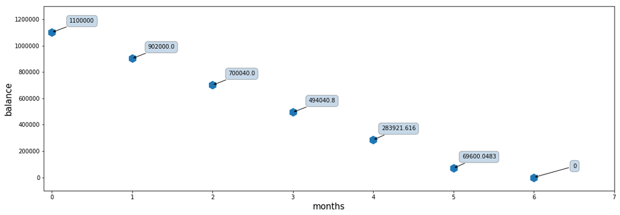

```python
plt.figure(figsize=(18,6))
plt.scatter(range(7),S,marker='h',s=200)
plt.xlabel('months',fontsize=15)
plt.ylabel('balance',fontsize=15)
plt.xlim(-0.1,7)
plt.ylim(-100000,1300000)
for i in range(7):
    plt.annotate(str(round(S[i],4)),xy=(i,S[i]),xytext=(75, 15),
        textcoords='offset points', ha='right', va='bottom',
        bbox=dict(boxstyle='round,pad=0.5', fc='steelblue', alpha=0.3),
        arrowprops=dict(arrowstyle = '->', connectionstyle='arc3,rad=0'));
```

```python
answer_dictionary[17] ='6'
```

[figure not shown]

### Задание 18 / Task 18

Найдите все значения параметра a, при каждом из которых уравнение

Find all the values of the parameter a, for each of which the equation

$4^x - (a - 1) * 2^{x + 1} + a^2 - 4 * a - 5 = 0$

имеет единственный корень.

has a single root.

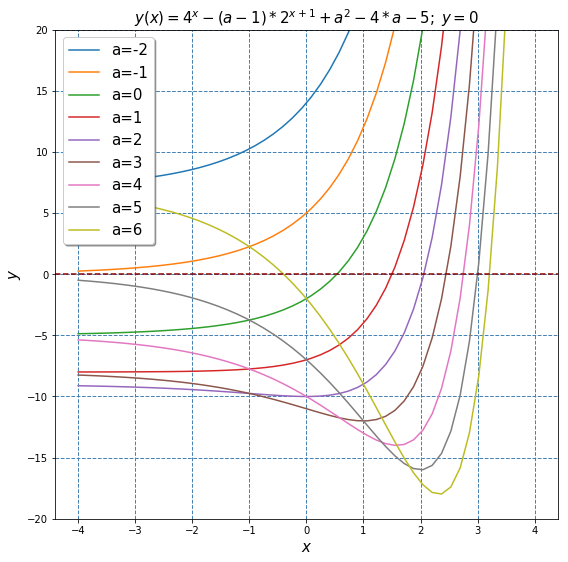

```python
def F(x,a): return 4 ** x - (a - 1) * 2 ** (x + 1) + a ** 2 - 4 * a - 5
X = numpy.linspace(-4, 4)

plt.figure(figsize=(9,9))
for a in [-2, -1, 0, 1, 2, 3, 4, 5, 6]:
    plt.plot(X, [F(x,a) for x in X], label='a='+str(a))

plt.axhline(0, c='darkred', ls='--')
plt.legend(shadow=True, loc=2, fontsize=15)
plt.xlabel(r'$x$', fontsize=15)
plt.ylabel(r'$y$', fontsize=15)
plt.ylim(-20,20)

plt.title(r'$y(x) = 4^x - (a - 1) * 2^{x + 1} + a^2 - 4 * a - 5; \; y = 0$', fontsize=15)
plt.grid(c='steelblue', ls='--', lw=1);
```

$4^x - (a - 1) * 2^{x + 1} + a^2 - 4 * a - 5 = 0$

$(2^x)^2 - 2 * (a - 1) * 2^x + a^2 - 4 * a - 5 = 0$

$D = (2 * (a - 1))^2 - 4 * (a^2 - 4 * a - 5) = 4 * a^2 - 8 * a + 4 - 4 * a^2 + 16 * a + 20 = 8 * a + 24$

Исходное уравнение имеет один корень:

- дискриминант D равен нулю,
- дискриминант D больше нуля, но один из корней меньше нуля или равен нулю, т.к. $2^x = t$ не имеет решений $t \leq 0$.

The original equation has one root:

- the discriminant D is equal to zero,
- the discriminant D is greater than zero, but one of the roots is less than zero or zero because $2^x = t$ does not have solutions if $t \leq 0$.

$\begin{cases} 8 * a + 24 \geq 0 \\ a - 1 - \sqrt{2 * a + 6} \leq 0 \\ a - 1 + \sqrt{2 * a + 6} > 0 \end{cases} \iff \begin{cases} a \geq -3 \\ \sqrt{2 * a + 6} \geq a - 1\\ \sqrt{2 * a + 6} > 1 - a \end{cases} \; (*)$

$1) \; a - 1 > 0 \; (1 - a < 0)$

1.1

$\sqrt{2 * a + 6} \geq a - 1$

$2 * a + 6 \geq a^2 - 2 * a + 1$

$a^2 - 4 * a - 5 \leq 0$

$(a + 1) * (a - 5) \leq 0$

1.2

$\sqrt{2 * a + 6} > 1 - a$

$a > -3$

$1 < a \leq 5$

$2) \; a - 1 = 0$

При a = 1 все неравенства $(*)$ выполняются.

For a = 1, all the inequalities $ (*) $ are satisfied.

$3) \; a - 1 < 0 \; (1 - a > 0)$

3.1

$\sqrt{2 * a + 6} \geq a - 1$

$a \geq - 3$

3.2

$\sqrt{2 * a + 6} > 1 - a$

$a^2 - 4 * a - 5 < 0$

$(a + 1) * (a - 5) < 0$

$-1 < a < 1$

$1), 2), 3) \implies a \in (-1;5]$

### Ответ / Answer: $(-1;5]$

```python
answer_dictionary[18] ='(−1;5]'
```

[figure not shown]

### Задание 19 / Task 19

В одном из заданий на конкурсе бухгалтеров требуется выдать премии сотрудникам некоторого отдела на общую сумму 600 000 рублей

(размер премии каждого сотрудника - целое число, кратное 1000).

Бухгалтеру дают распределение премий, и он должен из выдать без сдачи и размена,

имея 100 купюр по 1000 рублей и 100 купюр по 5000 рублей.

а) Удастся ли выполнить задание, если в отделе 40 сотрудников и все должны получить поровну?

б) Удастся ли выполнить задание, если ведущему специалисту надо выдать 40 000 рублей, а остальное поделить поровну на 70 сотрудников?

в) При каком наибольшем количестве сотрудников в отделе задание удастся выполнить при любом распределении размеров премий?

In one of the tasks at the bookkeeper competition,

it is required to award bonuses to employees of a certain department for a total of 600,000 rubles

(the size of each employee's bonus is an integer multiple of 1000).

The bookkeeper distributes the bonuses, and he must give out without short change and exchange,

having 100 bills of 1,000 rubles and 100 bills of 5000 rubles each.

a) Will the task be completed if there are 40 employees in the department and everyone should receive the same amount?

b) Will the task be completed if the leading specialist should get 40,000 rubles, and the rest be divided equally among 70 employees?

c) What is the maximum number of employees in the department, the task can be fulfilled with any distribution of premium sizes?

а)

Премия одного сотрудника равна: / The bonus of one employee is:

$600 000 : 40 = 15 000$

Сумма кратна 1 000 и 5 000. / The sum is a multiple of 1 000 and 5 000.

Пример распределения купюр: / Example of allocation of denominations:

| Количество сотрудников | Купюры по 1 000 рублей | Купюры по 5 000 рублей |
| --- | --- | --- |
| Number of employees | Denominations of 1 000 rubles | Denominations of 5 000 rubles |
| 20 | 5 * 20 = 100 | 2 * 20 = 40 |
| 20 | 0 | 3 * 20 = 60 |

б)

Сумма после выплаты ведущему специалисту:

The amount after the payment to the lead specialist:

$600 000 - 40 000 = 560 000$

Премия каждого из оставшихся 70 сотрудников:

The bonus for each of the remaining 70 employees:

$560 000 : 70 = 8 000$

$8 000 = 1 * 5 000 + 3 * 1 000$

Для выдачи премии каждому сотруднику необходимо минимум 3 купюры по 1 000 рублей.

To issue the bonus, each employee needs at least 3 denominations for 1 000 rubles.

Для 70 сотрудников необходимо 3 * 70 = 210 купюр, а имеется только 100.

For 70 employees, it needs 3 * 70 = 210 denominations, and there are only 100 by the task conditions.

в)

Распределить премию при условии, что ведущий специалист получит большую сумму, чем одинаковые премии остальных сотрудников,

можно при наличии 119 человек в отделе:

- 118 человек получат премию 5 000 рублей ($100 * 1 = 100$ купюр по 5 000 рублей, $18 * 5 = 90$ купюр по 1 000 рублей),
- ведущий специалист получит 10 000 (10 купюр по 1 000 рублей).

To distribute the bonus provided that the lead specialist receives a larger amount

than the equal premiums of the remaining employees,

it needs to have maximum 119 people in the department:

- 118 people will receive a premium of 5,000 rubles ($100 * 1 = 100$ of denominations of 5,000 rubles, $18 * 5 = 90$ of denominations of 1,000 rubles each),
- the leading specialist will receive 10 000 (10 denominations of 1,000 rubles).

### Ответ / Answer: а) да; б) нет; в) 119

```python
answer_dictionary[19] ='а) да; б) нет; в) 119'
```

## Ответы / Answers

| 1 | 2 | 3 | 4 | 5 | 6 | 7 | 8 | 9 | 10 | 11 | 12 |
| --- | --- | --- | --- | --- | --- | --- | --- | --- | --- | --- | --- |
| 5 | 7 | 8 | 0.52 | 1.8 | 27 | -3 | 10 | 12 | 90 | 26 | -25 |

| 13 | 14 | 15 | 16 | 17 | 18 | 19 |
| --- | --- | --- | --- | --- | --- | --- |
| а) $arctg (\large{\frac{7}{3}}$$) \pm \pi * k,$ $- \large{\frac{\pi}{4}}$$ \pm \pi * m;$ $k,m \in \mathbb{N}$ б) $-\large{\frac{\pi}{4}}$$; arctg (\large{\frac{7}{3}}$$); \large{\frac{3*\pi}{4}}$ | б) $arctg (\frac{\sqrt{2}}{2})$ | $[2;4)$ | 3 ∨ 15 | 6 | (−1;5] | а) да; б) нет; в) 119 |

```python
answer_dictionary
```

```
{1: '5',
 2: '7',
 3: '8',
 4: '0.52',
 5: '1.8',
 6: '27',
 7: '-3',
 8: '10',
 9: '12',
 10: '90',
 11: '26',
 12: '-25',
 13: 'а) arctg(7/3)±π∗k, -π/4±π∗m; k,m∈ℕ; б) -π/4,arctg(7/3),3*π/4',
 14: 'б) arctg(√2/2)',
 15: '[2;4)',
 16: '3 ∨ 15',
 17: '6',
 18: '(−1;5]',
 19: 'а) да; б) нет; в) 119'}
```

[figure not shown]